# Project: Investigating the TMBD Movie Dataset

- Introduction
- Data Wrangling
- Exploratory Data Analysis
- Conclusions

## Introduction

> This data set contains information of about 10,000 movies collected from The Movie Database (TMDb).

> There are 21 columns in this dataset -

```
   id - Movie Identification Number
   imdb_id - IMDB Identification Number
   popularity - Movie popularity score
   budget - Amount spent on movie
   revenue - Amount generated from movie
   original_title - Movie title
   cast - Actors in movie
   homepage - Homepage
   director - Movie directors
   tagline - Tagline
   keywords - Keywords
   overview - Overview
   runtime - Duration of movie in minutes
   genres - Movie genre
   production_companies - Production companies
   release_date - Movie release date (dd-mm-yyyy)
   vote_count - Number of ratings for movie
   vote_average - Average rating for movie
   release_year - Movie release year (yyyy)
   budget_adj - Adjusted amount spent on movie
   revenue_adj - Adjusted amout generated from movie
```

> In this project, the following will be looked into;

```
   How the number of movies released per year has changed over the years.

   How the vote count has changed over the years.
```

```python
import pandas as pd
import numpy as np
import matplotlib.pyplot as plt
%matplotlib inline
```

## Data Wrangling

### General Properties

```python
#load data and display the first 5 and last 5 rows of data
movie_df = pd.read_csv('tmdb-movies.csv')
print(movie_df.head())
print(movie_df.tail())
```

```
       id    imdb_id  popularity     budget     revenue  \
0  135397  tt0369610   32.985763  150000000  1513528810
1   76341  tt1392190   28.419936  150000000   378436354
2  262500  tt2908446   13.112507  110000000   295238201
3  140607  tt2488496   11.173104  200000000  2068178225
4  168259  tt2820852    9.335014  190000000  1506249360

                 original_title  \
0                Jurassic World
1            Mad Max: Fury Road
2                     Insurgent
3  Star Wars: The Force Awakens
4                     Furious 7

                                                cast  \
```

[output cut: 106 more lines]

```python
#check number of rows and columns in data
movie_df.shape
```

```
(10866, 21)
```

#### There are a total of 10,866 rows and 21 columns in the TMDB movie dataset

```python
movie_df.info()
```

```
<class 'pandas.core.frame.DataFrame'>
RangeIndex: 10866 entries, 0 to 10865
Data columns (total 21 columns):
 #   Column                Non-Null Count  Dtype
---  ------                --------------  -----
 0   id                    10866 non-null  int64
 1   imdb_id               10856 non-null  object
 2   popularity            10866 non-null  float64
 3   budget                10866 non-null  int64
 4   revenue               10866 non-null  int64
 5   original_title        10866 non-null  object
 6   cast                  10790 non-null  object
 7   homepage              2936 non-null   object
 8   director              10822 non-null  object
 9   tagline               8042 non-null   object
 10  keywords              9373 non-null   object
 11  overview              10862 non-null  object
 12  runtime               10866 non-null  int64
 13  genres                10843 non-null  object
 14  production_companies  9836 non-null   object
 15  release_date          10866 non-null  object
 16  vote_count            10866 non-null  int64
 17  vote_average          10866 non-null  float64
 18  release_year          10866 non-null  int64
 19  budget_adj            10866 non-null  float64
 20  revenue_adj           10866 non-null  float64
dtypes: float64(4), int64(6), object(11)
memory usage: 1.7+ MB
```

#### The table headers are labelled properly and do not need any modifications.

#### There are 9 columns with missing values.

#### There are 10 missing imdb_id values, imdb_id is a unique identifier so rows with missing imdb_id will be dropped in order to have a more accurate dataset.

#### The other coulmns with missing values will not be dropped but instead null values will be replaced with 'Not Available' to not only give a cleaner dataset but to also prevent our int values from being presented as float.

#### The Dtype for release_date is currently in object and will be changed to datetime.

#### The Dtype for budget_adj and revenue_adj are currently in float64 and will be changed to int.

```python
movie_df.describe()
```

|  | id | popularity | budget | revenue | runtime | vote_count | vote_average | release_year | budget_adj | revenue_adj |
| --- | --- | --- | --- | --- | --- | --- | --- | --- | --- | --- |
| count | 10866.000000 | 10866.000000 | 1.086600e+04 | 1.086600e+04 | 10866.000000 | 10866.000000 | 10866.000000 | 10866.000000 | 1.086600e+04 | 1.086600e+04 |
| mean | 66064.177434 | 0.646441 | 1.462570e+07 | 3.982332e+07 | 102.070863 | 217.389748 | 5.974922 | 2001.322658 | 1.755104e+07 | 5.136436e+07 |
| std | 92130.136561 | 1.000185 | 3.091321e+07 | 1.170035e+08 | 31.381405 | 575.619058 | 0.935142 | 12.812941 | 3.430616e+07 | 1.446325e+08 |
| min | 5.000000 | 0.000065 | 0.000000e+00 | 0.000000e+00 | 0.000000 | 10.000000 | 1.500000 | 1960.000000 | 0.000000e+00 | 0.000000e+00 |
| 25% | 10596.250000 | 0.207583 | 0.000000e+00 | 0.000000e+00 | 90.000000 | 17.000000 | 5.400000 | 1995.000000 | 0.000000e+00 | 0.000000e+00 |
| 50% | 20669.000000 | 0.383856 | 0.000000e+00 | 0.000000e+00 | 99.000000 | 38.000000 | 6.000000 | 2006.000000 | 0.000000e+00 | 0.000000e+00 |
| 75% | 75610.000000 | 0.713817 | 1.500000e+07 | 2.400000e+07 | 111.000000 | 145.750000 | 6.600000 | 2011.000000 | 2.085325e+07 | 3.369710e+07 |
| max | 417859.000000 | 32.985763 | 4.250000e+08 | 2.781506e+09 | 900.000000 | 9767.000000 | 9.200000 | 2015.000000 | 4.250000e+08 | 2.827124e+09 |

#### The dataset contains information of movies released between 1960 and 2015.

#### Although there were no missing values for the buget, revenue, budget_adj and revenue_adj columns, there are rows with 0 values for these columns. I will perform a count on the rows where values are greater than 0 to determine whether these rows can be used in my EDA.

```python
#check for rows with non-zero values
columns = ['budget','revenue','budget_adj','revenue_adj']
def non_zero_values():
    for col in columns:
        print(movie_df[movie_df[col] > 0].shape)

non_zero_values()
```

```
(5170, 21)
(4850, 21)
(5170, 21)
(4850, 21)
```

#### For the budget and budget_adj columns, 5,170 rows out of 10,866 rows have values greater than 0.

#### For the revenue and revenue_adj columns, 4,850 rows out of 10,866 rows have values greater than 0.

```python
#check for duplicate entries
sum(movie_df.duplicated())
```

```
1
```

#### There is an instance of a duplicated row

```python
#check for uniques values
movie_df.nunique()
```

```
id                      10865
imdb_id                 10855
popularity              10814
budget                    557
revenue                  4702
original_title          10571
cast                    10719
homepage                 2896
director                 5067
tagline                  7997
keywords                 8804
overview                10847
runtime                   247
genres                   2039
production_companies     7445
release_date             5909
vote_count               1289
vote_average               72
release_year               56
budget_adj               2614
revenue_adj              4840
dtype: int64
```

#### Now that the loaded data has been thoroughly checked, I will be proceeding to make the necessary changes highlighted above.

### Data Cleaning

```python
#create copy of dataset
movie_clean = movie_df.copy()
```

```python
# dropping rows with missing imdb_id
movie_clean = movie_clean[movie_clean['imdb_id'].notnull()]
```

```python
# checking that the rows with missing imdb_id have been dropped
print(movie_clean.info())
print(movie_clean.shape)
```

```
<class 'pandas.core.frame.DataFrame'>
Int64Index: 10856 entries, 0 to 10865
Data columns (total 21 columns):
 #   Column                Non-Null Count  Dtype
---  ------                --------------  -----
 0   id                    10856 non-null  int64
 1   imdb_id               10856 non-null  object
 2   popularity            10856 non-null  float64
 3   budget                10856 non-null  int64
 4   revenue               10856 non-null  int64
 5   original_title        10856 non-null  object
 6   cast                  10780 non-null  object
 7   homepage              2934 non-null   object
 8   director              10816 non-null  object
 9   tagline               8039 non-null   object
 10  keywords              9369 non-null   object
 11  overview              10853 non-null  object
 12  runtime               10856 non-null  int64
 13  genres                10835 non-null  object
 14  production_companies  9831 non-null   object
 15  release_date          10856 non-null  object
 16  vote_count            10856 non-null  int64
 17  vote_average          10856 non-null  float64
 18  release_year          10856 non-null  int64
 19  budget_adj            10856 non-null  float64
 20  revenue_adj           10856 non-null  float64
dtypes: float64(4), int64(6), object(11)
memory usage: 1.8+ MB
None
(10856, 21)
```

#### The rows with missing imdb_id have been dropped and the movie dataframe now has 10,856 entries(rows).

```python
# filling other columns with missing values
movie_clean = movie_clean.fillna('Not Available',inplace=False)
# this code was obtained from the pandas documentation file - https://pandas.pydata.org/docs/reference/api/pandas.DataFrame.fillna.html
```

```python
# checking that missing values have been filled
movie_clean.info()
```

```
<class 'pandas.core.frame.DataFrame'>
Int64Index: 10856 entries, 0 to 10865
Data columns (total 21 columns):
 #   Column                Non-Null Count  Dtype
---  ------                --------------  -----
 0   id                    10856 non-null  int64
 1   imdb_id               10856 non-null  object
 2   popularity            10856 non-null  float64
 3   budget                10856 non-null  int64
 4   revenue               10856 non-null  int64
 5   original_title        10856 non-null  object
 6   cast                  10856 non-null  object
 7   homepage              10856 non-null  object
 8   director              10856 non-null  object
 9   tagline               10856 non-null  object
 10  keywords              10856 non-null  object
 11  overview              10856 non-null  object
 12  runtime               10856 non-null  int64
 13  genres                10856 non-null  object
 14  production_companies  10856 non-null  object
 15  release_date          10856 non-null  object
 16  vote_count            10856 non-null  int64
 17  vote_average          10856 non-null  float64
 18  release_year          10856 non-null  int64
 19  budget_adj            10856 non-null  float64
 20  revenue_adj           10856 non-null  float64
dtypes: float64(4), int64(6), object(11)
memory usage: 1.8+ MB
```

#### Missing values have been replaced with 'Not Available'

```python
#Changing release_date Dtype to datetime from object
movie_clean['release_date'] = pd.to_datetime(movie_clean['release_date'])
print(movie_clean['release_date'].dtypes)
```

```
datetime64[ns]
```

```python
#Changing budget_adj and revenue_adj Dtype to int64 from float64
columns = ['budget_adj','revenue_adj']
def change_dtype():
    for col in columns:
        movie_clean[col] = movie_clean[col].astype(np.int64)
        print(movie_clean[col].dtypes)
change_dtype()
```

```
int64
int64
```

#### All columns are now in the correct Dtype format

```python
# dropping duplicates in dataframe and confirming they have been dropped
movie_clean.drop_duplicates(inplace=True)
sum(movie_clean.duplicated())
```

```
0
```

#### There are currently no duplicate rows in the dataframe

#### My dataset has been cleaned and I will now be proceeding to run some exploratory data analysis.

## Exploratory Data Analysis

### How has the number of movies released per year changed?

### How many movies were released in each year, which years had the highest and lowest number of released movies? What months had the highest and lowest number of released movies?

```python
#create a subset for this EDA
movie_subset = movie_clean.copy()
movie_subset = movie_subset[['id','imdb_id','original_title','genres','release_date','release_year']]
```

```python
# number of movies released in each year
movie_subset.groupby(['release_year'])['imdb_id'].count()
```

```
release_year
1960     32
1961     31
1962     32
1963     34
1964     42
1965     35
1966     46
1967     40
1968     39
1969     31
1970     41
1971     55
1972     40
1973     55
```

[output cut: 43 more lines]

```python
# years with the highest number of released movies - Top 10
movie_subset['release_year'].value_counts().nlargest(10)
#.nlargest() function was extracted from https://stackoverflow.com/questions/35364601/group-by-and-find-top-n-value-counts-pandas
```

```
2014    699
2013    658
2015    628
2012    586
2011    540
2009    531
2008    496
2010    488
2007    436
2006    408
Name: release_year, dtype: int64
```

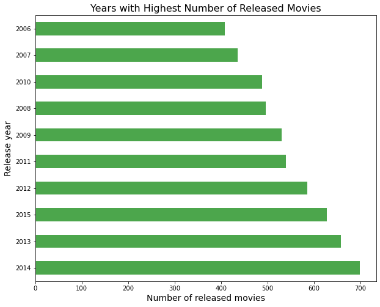

```python
# a horizontal bar chart showing the top 10 years with number of released movies
movie_subset['release_year'].value_counts().nlargest(10).plot(kind='barh', alpha=.7,color='green', figsize=(10,8));
plt.title('Years with Highest Number of Released Movies', fontsize=16)
plt.xlabel('Number of released movies', fontsize=14);
plt.ylabel('Release year', fontsize=14);
```

#### 2014 had the highest number of released movies - 699 movies

```python
# years with the lowest number of released movies - Bottom 10
movie_subset['release_year'].value_counts().nsmallest(10)
```

```
1961    31
1969    31
1960    32
1962    32
1963    34
1965    35
1968    39
1967    40
1972    40
1970    41
Name: release_year, dtype: int64
```

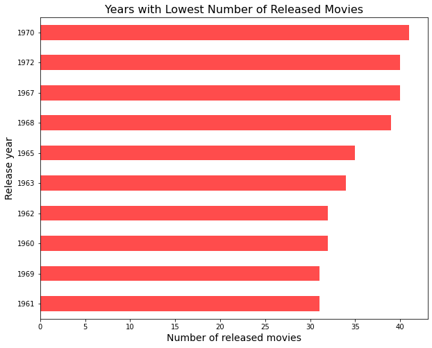

```python
# a horizontal bar chart showing the bottom 10 years with number of released movies
movie_subset['release_year'].value_counts().nsmallest(10).plot(kind='barh',alpha=.7,color='red',figsize=(10,8));
plt.title('Years with Lowest Number of Released Movies', fontsize=16)
plt.xlabel('Number of released movies', fontsize=14);
plt.ylabel('Release year', fontsize=14);
```

#### 1961 and 1969 had the lowest number of released movies - 31 movies

```python
# number of movies released each month
movie_subset['release_date'].dt.month.value_counts()
# function to extract month from date was extracted from - https://stackoverflow.com/questions/25146121/extracting-just-month-and-year-separately-from-pandas-datetime-column
```

```
9     1329
10    1151
12     984
8      917
1      915
6      827
3      822
11     814
5      809
7      799
4      797
2      691
Name: release_date, dtype: int64
```

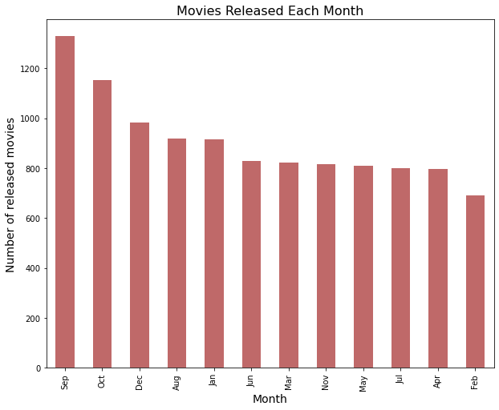

```python
# plot to display number of movies released each month
movie_subset['release_date'].dt.month.value_counts().plot(kind='bar',alpha=.7,color='brown',figsize=(10,8));
plt.title('Movies Released Each Month', fontsize=16)
plt.xlabel('Month', fontsize=14);
plt.xticks([0,1,2,3,4,5,6,7,8,9,10,11],['Sep','Oct','Dec','Aug','Jan','Jun','Mar','Nov','May','Jul','Apr','Feb'])
plt.ylabel('Number of released movies', fontsize=14);
```

#### The month of September has the highest number of released movies - 1,329 while the month of February has the lowest numberof released movies - 691

### Has the vote count for movies changed over the years? What years have the best and worst user ratings? What movies have the best and worst user ratings?

```python
#create subset for this EDA
movie_subset2 = movie_clean.copy()
movie_subset2 = movie_subset2[['id','imdb_id','original_title','genres','release_date','release_year','vote_count','vote_average']]
```

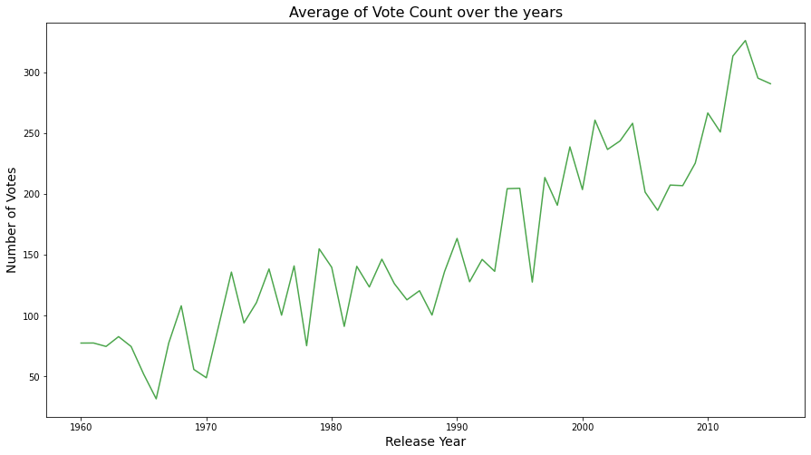

```python
movie_subset2.groupby(['release_year'])['vote_count'].mean().plot(kind='line',alpha=.7, figsize=(15,8), color='green');
plt.title('Average of Vote Count over the years', fontsize=16)
plt.xlabel('Release Year', fontsize=14);
plt.ylabel('Number of Votes', fontsize=14);
```

#### The plot above shows that there has been an increase in the number of vote count over the years.

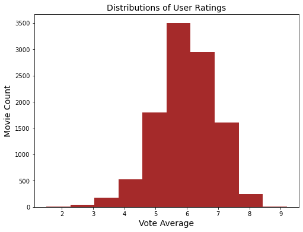

```python
# displaying user rating distribution
fig, ax = plt.subplots(figsize =(8,6))
ax.hist(movie_subset2['vote_average'], color = 'brown')
ax.set_title('Distributions of User Ratings', fontsize=14)
ax.set_xlabel('Vote Average', fontsize=14)
ax.set_ylabel('Movie Count', fontsize=14)
plt.show();
```

#### This distribution shows that a majority of the ratings are within the range of 4.8 - 7.6.

#### From my initial check of the dataset, there are 72 unique values for user ratings (vote_average column). To get a more detailed visualization of the user ratings for each year, I will be creating a new column to help categorize the user ratings into 4 distinct categories - Excellent, Good, Average and Poor. This will help give a better visualization of the data.

```python
#Bin edges used to cut the data into groups
bin_edges = [0,2.4,4.9,7.4,9.2]
#Labels for the 4 vote average categories
bin_names = ['poor','average','good','excellent']
#Create new column - ratings category
movie_subset2['ratings_category'] = pd.cut(movie_df['vote_average'],bin_edges,labels=bin_names)
movie_subset2.head()
```

|  | id | imdb_id | original_title | genres | release_date | release_year | vote_count | vote_average | ratings_category |
| --- | --- | --- | --- | --- | --- | --- | --- | --- | --- |
| 0 | 135397 | tt0369610 | Jurassic World | Action\|Adventure\|Science Fiction\|Thriller | 2015-06-09 | 2015 | 5562 | 6.5 | good |
| 1 | 76341 | tt1392190 | Mad Max: Fury Road | Action\|Adventure\|Science Fiction\|Thriller | 2015-05-13 | 2015 | 6185 | 7.1 | good |
| 2 | 262500 | tt2908446 | Insurgent | Adventure\|Science Fiction\|Thriller | 2015-03-18 | 2015 | 2480 | 6.3 | good |
| 3 | 140607 | tt2488496 | Star Wars: The Force Awakens | Action\|Adventure\|Science Fiction\|Fantasy | 2015-12-15 | 2015 | 5292 | 7.5 | excellent |
| 4 | 168259 | tt2820852 | Furious 7 | Action\|Crime\|Thriller | 2015-04-01 | 2015 | 2947 | 7.3 | good |

#### The ratings_category column has been created.

#### Movies with an average vote between 7.5 - 9.2 = Excellent

#### Movies with an average vote between 5.0 - 7.4 = Good

#### Movies with an average vote between 2.5 - 4.9 = Average

#### Movies with an average vote between 0 - 2.4 = Poor

```python
#getting count of movies in each category
movie_subset2['ratings_category'].value_counts()
```

```
good         8968
average      1403
excellent     466
poor           18
Name: ratings_category, dtype: int64
```

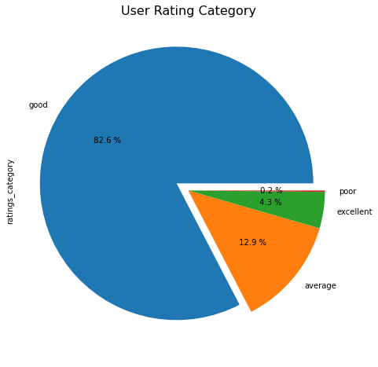

```python
#pie chart to display the ratio of movies in each ratings category
movie_subset2['ratings_category'].value_counts().plot(kind='pie',figsize=(8,8),autopct = '% 1.1f %%', explode=(0.1,0,0,0));
plt.title('User Rating Category', fontsize=16);
#code extracted from - https://stackoverflow.com/questions/21090316/plotting-pandas-dataframes-in-to-pie-charts-using-matplotlib
```

#### 82.6% of the movies released fall under the Good ratings category

#### I will do some further analysis to see what years have the best and worst ratings based on vote count and vote average.

```python
# movies with highest user rating
movie_df.groupby(['original_title'])[['vote_average','release_year']].max().nlargest(20,'vote_average')
```

| original_title | vote_average | release_year |
| --- | --- | --- |
| The Story of Film: An Odyssey | 9.2 | 2011 |
| The Mask You Live In | 8.9 | 2015 |
| Black Mirror: White Christmas | 8.8 | 2014 |
| Life Cycles | 8.8 | 2010 |
| Pink Floyd: Pulse | 8.7 | 2006 |
| Opeth: In Live Concert At The Royal Albert Hall | 8.6 | 2010 |
| A Personal Journey with Martin Scorsese Through American Movies | 8.5 | 1995 |
| Dave Chappelle: Killin' Them Softly | 8.5 | 2000 |
| Doctor Who: The Time of the Doctor | 8.5 | 2013 |
| John Mayer: Where the Light Is Live in Los Angeles | 8.5 | 2008 |
| Queen - Rock Montreal | 8.5 | 1981 |
| The Art of Flight | 8.5 | 2011 |
| Bill Hicks: Relentless | 8.4 | 1992 |
| Depeche Mode: 101 | 8.4 | 1989 |
| Foo Fighters: Live at Wembley Stadium | 8.4 | 2008 |
| Guten Tag, RamÃ³n | 8.4 | 2013 |
| Rush: Beyond the Lighted Stage | 8.4 | 2010 |
| Stop Making Sense | 8.4 | 1984 |
| The Jinx: The Life and Deaths of Robert Durst | 8.4 | 2015 |
| The Making of The Walking Dead | 8.4 | 2010 |

```python
# movies with lowest user rating
movie_df.groupby(['original_title'])[['vote_average','release_year']].min().nsmallest(20,'vote_average')
```

| original_title | vote_average | release_year |
| --- | --- | --- |
| Manos: The Hands of Fate | 1.5 | 1966 |
| Transmorphers | 1.5 | 2007 |
| Jurassic Shark | 2.0 | 2012 |
| Birdemic: Shock and Terror | 2.1 | 2010 |
| Sand Sharks | 2.1 | 2011 |
| Superbabies: Baby Geniuses 2 | 2.1 | 2004 |
| Atlantic Rim | 2.2 | 2013 |
| Foodfight! | 2.2 | 2012 |
| The Sleeper | 2.2 | 2012 |
| Dracula 3000 | 2.3 | 2004 |
| Going Overboard | 2.3 | 1989 |
| Age of Tomorrow | 2.4 | 2014 |
| American Warships | 2.4 | 2012 |
| Jersey Shore Massacre | 2.4 | 2014 |
| Mega Shark vs. Crocosaurus | 2.4 | 2010 |
| Slow Torture Puke Chamber | 2.4 | 2010 |
| The Contractor | 2.4 | 2007 |
| The Ouija Experiment 2: Theatre of Death | 2.4 | 2015 |
| 2010: Moby Dick | 2.5 | 2010 |
| All About Anna | 2.5 | 2005 |

#### 18 of the worst 20 movies were also released in the 2000s.

```python
# creating a df to have only movies with an excellent rating
excellent_df = movie_subset2.query('ratings_category == "excellent"')
excellent_df.head()
```

|  | id | imdb_id | original_title | genres | release_date | release_year | vote_count | vote_average | ratings_category |
| --- | --- | --- | --- | --- | --- | --- | --- | --- | --- |
| 3 | 140607 | tt2488496 | Star Wars: The Force Awakens | Action\|Adventure\|Science Fiction\|Fantasy | 2015-12-15 | 2015 | 5292 | 7.5 | excellent |
| 7 | 286217 | tt3659388 | The Martian | Drama\|Adventure\|Science Fiction | 2015-09-30 | 2015 | 4572 | 7.6 | excellent |
| 9 | 150540 | tt2096673 | Inside Out | Comedy\|Animation\|Family | 2015-06-09 | 2015 | 3935 | 8.0 | excellent |
| 12 | 264660 | tt0470752 | Ex Machina | Drama\|Science Fiction | 2015-01-21 | 2015 | 2854 | 7.6 | excellent |
| 27 | 207703 | tt2802144 | Kingsman: The Secret Service | Crime\|Comedy\|Action\|Adventure | 2015-01-24 | 2015 | 3833 | 7.6 | excellent |

```
release_year
1960     2
1961     1
1962     2
1963     2
1964     1
1965     1
1966     2
1967     3
1968     1
1970     2
1971     1
1972     4
1973     3
1974     5
```

[output cut: 42 more lines]

[figure not shown]

```python
# number of excellent movies released in each year
excellent_df.groupby(['release_year'])['release_year'].count().plot(kind='bar',figsize=(15,6),color='green');
plt.title('Best User Ratings', fontsize=16)
plt.xlabel('Release Year', fontsize=14);
plt.ylabel('Number of Movies with Excellent Rating', fontsize=14);
print(excellent_df.groupby(['release_year'])['release_year'].count())
```

#### 2014 had the highest number of movies rated Excellent

```python
# creating a df to have only movies with a poor rating
poor_df = movie_subset2.query('ratings_category == "poor"')
poor_df.head()
```

|  | id | imdb_id | original_title | genres | release_date | release_year | vote_count | vote_average | ratings_category |
| --- | --- | --- | --- | --- | --- | --- | --- | --- | --- |
| 546 | 309063 | tt3727824 | The Ouija Experiment 2: Theatre of Death | Horror | 2015-01-13 | 2015 | 10 | 2.4 | poor |
| 1072 | 275619 | tt3677466 | Age of Tomorrow | Thriller\|Science Fiction\|Action | 2014-06-10 | 2014 | 10 | 2.4 | poor |
| 1205 | 288154 | tt2713642 | Jersey Shore Massacre | Horror\|Comedy | 2014-08-22 | 2014 | 14 | 2.4 | poor |
| 2280 | 52454 | tt1705773 | Mega Shark vs. Crocosaurus | Action\|Horror\|Science Fiction | 2010-12-21 | 2010 | 15 | 2.4 | poor |
| 2298 | 68523 | tt1937329 | Slow Torture Puke Chamber | Horror | 2010-07-27 | 2010 | 11 | 2.4 | poor |

```
release_year
1966    1
1989    1
2004    2
2007    1
2010    3
2011    1
2012    4
2013    2
2014    2
2015    1
Name: release_year, dtype: int64
```

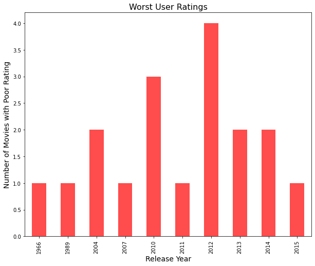

```python
# creating a bar chart for Worst 10 years
poor_df.groupby(['release_year'])['release_year'].count().plot(kind='bar',alpha=.7, figsize=(10,8), color='red');
plt.title('Worst User Ratings', fontsize=16);
plt.xlabel('Release Year', fontsize=14);
plt.ylabel('Number of Movies with Poor Rating', fontsize=14);
print(poor_df.groupby(['release_year'])['release_year'].count())
```

#### 2012 is recorded to have the highest number of poor ratings

#### Considering that more movies were released in the 2000s, I will do some further analysis to determine which years have the worst and best movie ratings

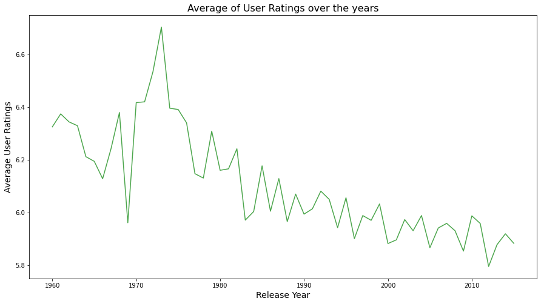

```python
movie_subset2.groupby(['release_year'])['vote_average'].mean().plot(kind='line',alpha=.7, figsize=(15,8), color='green');
plt.title('Average of User Ratings over the years', fontsize=16)
plt.xlabel('Release Year', fontsize=14);
plt.ylabel('Average User Ratings', fontsize=14);
```

#### From the plot above, we can tell that there is a decline in the user ratings with the 1970s having the best user rating.

## Conclusions

#### From the analysis done, the following can be concluded:

1. The number of movies released per year has increased over the years with about 50% of movies being released after 2005. It is also interesting to note that over the years, the month of September has recorded the highest number of movie releases with 1,329 movies released between 1960 - 2015.
2. Although the number of votes has increased over the years, there has been a decline in the average user ratings with the 1970s having the best user ratings. Viewer's favourite in terms of vote average is The Story of Film: An Odyssey while the least favourite movies are Manos: The Hands of Fate and Transmorphers.

#### A limitation faced in this analysis was the non-viability of the budget and revenue columns, having less than 50% non-zero values. Due to this, I was unable to find a correlation between user ratings and budget and also doing analysis on the profit made on movies over the years.